# Linear classification methods

Oct 30, 2019

First, we load a few R packages

```r
library(tidyverse)
library(caret)
library(pROC)
library(here)
```

**Attribution**: A lot of the material for this lecture came from the following resources

- [An Introduction to Statistical Learning, 2013](https://www.springer.com/us/book/9781461471370) by James, Witten, Hastie and Tibshirani
- The dsbook from Rafael Irizarry

# Motivation

In the previous lectures, we have learned about the goal of machine learning algorithms, where decisions made are based on algorithms built on data. The data we have often comes in the form of an *outcome* we want to predict and the *features* that we will use to predict the outcome. This setting is often called a **supervised learning** (as opposed to the **unsupervised learning**) setting without an *outcome* variablethat we will talk about later this term.

The general idea is that we build the algorithm using the data that includes the outcome so that in the future we can predict the outcome only using the features. Here we will use $Y$ to denote the outcome and $X_1, \dots, X_p$ to denote features. Note that the features are sometimes referred to as predictors or covariates and the outcome is sometimes referred to as a response variable.

If the outcome $Y$ is quantitiative, something like linear regression is very useful for predicting a quantitative response. But in many situtions, the responsible variable is qualitative (or categorial). Predicting a qualitative response $Y$ is referred to as *classification* since it invovles assigning each observation to a cateory or class.

So the general set-up is as follows. Given a set of predictors $X_{ij}$ and and qualitative outcome $Y_i$, we can collect data to *classify* or *predict* which class or cateogory each outcome (or observation) belongs in:

| outcome | feature_1 | feature_2 | feature_3 | feature_4 | feature_5 |
| --- | --- | --- | --- | --- | --- |
| Y_1 | X_1,1 | X_1,2 | X_1,3 | X_1,4 | X_1,5 |
| Y_2 | X_2,1 | X_2,2 | X_2,3 | X_2,4 | X_2,5 |
| Y_3 | X_3,1 | X_3,2 | X_3,3 | X_3,4 | X_3,5 |
| Y_4 | X_4,1 | X_4,2 | X_4,3 | X_4,4 | X_4,5 |
| Y_5 | X_5,1 | X_5,2 | X_5,3 | X_5,4 | X_5,5 |
| Y_6 | X_6,1 | X_6,2 | X_6,3 | X_6,4 | X_6,5 |
| Y_7 | X_7,1 | X_7,2 | X_7,3 | X_7,4 | X_7,5 |
| Y_8 | X_8,1 | X_8,2 | X_8,3 | X_8,4 | X_8,5 |
| Y_9 | X_9,1 | X_9,2 | X_9,3 | X_9,4 | X_9,5 |
| Y_10 | X_10,1 | X_10,2 | X_10,3 | X_10,4 | X_10,5 |

Today we will focus on the three of the most widely used classifiers:

1. Linear and Logistic regression
2. Linear and Quadratic discriminant analysis
3. $K$-nearest neighbors

In the next several lectures, we will discuss other methods including, trees, random forests, and boosting, and support vector machines.

# Data

For this lecture, we will use the [Fashion-MNIST](https://www.kaggle.com/zalando-research/fashionmnist) dataset from Kaggle. The motiviating question is

> Can we build a classifer to accurately classify images of pieces of clothing?

The data consists of a training set of 60,000 images and a test set of 10,000 examples. We will assume the test set is the only data available for the purposes of this lecture (mostly because it’s 1/6 of the size of the training set!).

For example, we want to build a classifier to recognize this image as a pair of pants:

[figure not shown]

[[ image source](http://www.blackdiamondequipment.com/on/demandware.static/-/Sites-bdel/default/dw3a8bc553/products/S18_Product_Images/Apparel/XZD6_030_Ash_M_NotionPants_Front.jpg)]

And the classifier should be able to recognize this image as shoe:

[figure not shown]

[[ image source](https://c.static-nike.com/a/images/f_auto,b_rgb:f5f5f5,w_440/wbwotdyvjbgtckofir0g/converse-chuck-taylor-all-star-looney-tunes-high-top-little-big-kids-shoe-XMT4Sz.jpg)]

The fashion MNIST dataset contains a set of images of clothing or fashion pieces. Each observation $Y_i$ is labeled one of the following:

- `0` = T-shirt/top
- `1` = Trouser
- `2` = Pullover
- `3` = Dress
- `4` = Coat
- `5` = Sandal
- `6` = Shirt
- `7` = Sneaker
- `8` = Bag
- `9` = Ankle boot

Similar to the digits images dataset we looked at in the dimensionality reduction lecture, the images are converted into $28 \times 28$ pixels and for each we obtain an gray scale intensity between 0 (white) to 256 (black). We will explore this data set using some common machine learning algorithms for classification.

## Data import

First, let’s read in the `fashion-mnist_test.csv` dataset using the `read_csv()` function in the `readr` package.

```r
url <- here("data", "fashion-mnist_test.csv")
if(!exists("fashion")) fashion <- read_csv(url)
X <- fashion %>% select(-label) %>% as.matrix() # save just pixels
fashion_labels <- fashion %>% pull(label)
```

What are the outcomes and features? We can look at the first three images to see what they look like.

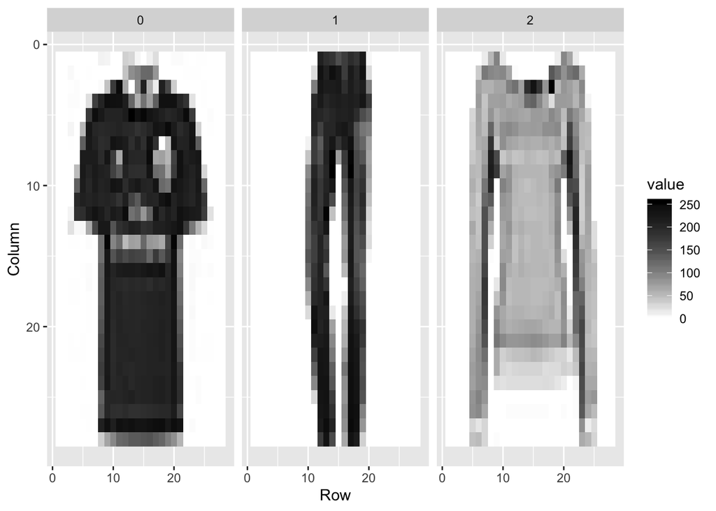

```r
tmp <- lapply( c(1:3), function(i){
    expand.grid(Row=1:28, Column=1:28) %>%
      mutate(id=i, label=fashion$label[i],
             value = unlist(fashion[i,-1])) })
tmp <- Reduce(rbind, tmp)
tmp %>% ggplot(aes(Row, Column, fill=value)) +
    geom_raster() +
    scale_y_reverse() +
    scale_fill_gradient(low="white", high="black") +
    facet_grid(.~label)
```

Similar to the handwritten digits dataset, the features $X_{i,1}, \dots, X_{i,784}$ (28x28 pixels) can take values from 0 (white) to 256 (black):

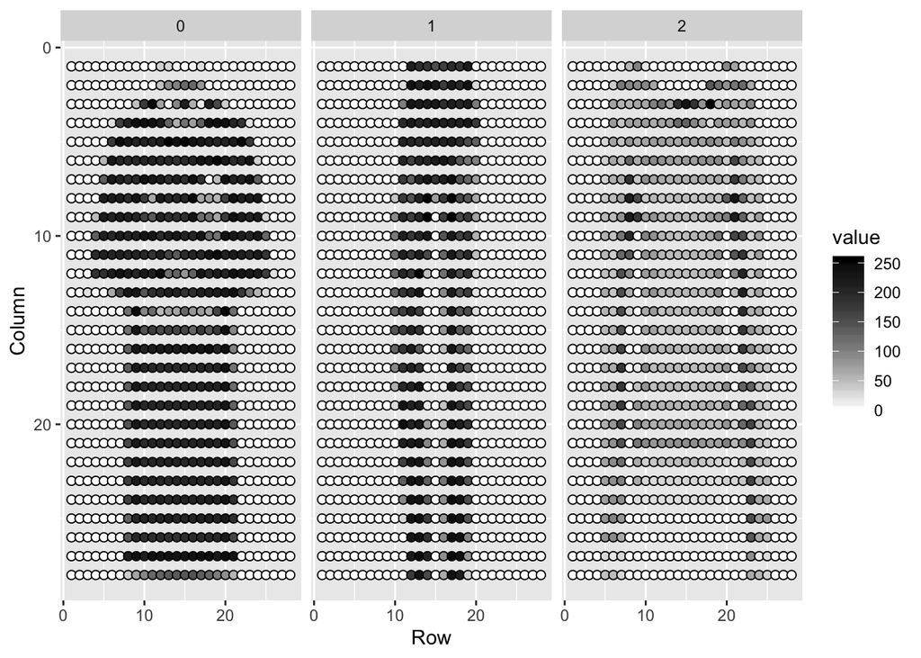

```r
tmp %>% ggplot(aes(Row, Column, fill=value)) +
    geom_point(pch=21,cex=2) +
    scale_y_reverse() +
    scale_fill_gradient(low="white", high="black") +
    facet_grid(.~label)
```

We use bold face to denote this vector of predictors

$$\mathbf{X}_i = (X_{i,1}, \dots, X_{i,784})$$

Even though the `label` here is a whole number between 0 and 10, this is a qualtitative outcome (e.g. shirt, pants, shoes, etc). The machine learning task here is to build a predictor function, $f$ that converts $\mathbf{X}$ into a prediction category $\hat{Y}_i = f(\mathbf{X}_i)$ that minimizes the $d(Y,\hat{Y})$

## Data wrangling

For purposes of this lecture, we will focus only the `0`s (tshirt/top) and `5`s (sandals) observations:

```r
dat05 <- fashion %>%
  filter(fashion_labels %in% c(0,5))

## labels are not numbers
dat05 <- mutate(dat05, label = as.factor(label))
```

### Feature engineering

To distinguish 0s (shirts) from 5s (sandals), it might be enough to look at the number of non-white pixels in the upper-left and lower-right quadrants:

[figure not shown]

So we will define two features $X_1$ and $X_2$ as the percent of non-white pixels in these two quadrants, respectively. We add these two features to the `dat05` table

```r
row_column <- expand.grid(row=1:28, col=1:28)
ind1 <- which(row_column$col <= 14 & row_column$row <=14) # top left quandrant
ind2 <- which(row_column$col > 14 & row_column$row > 14) # bottom right quadrant
ind <- c(ind1,ind2)
X <- as.matrix(dat05[,-1]) # remove label column
X <- X>200
X1 <- rowSums(X[,ind1])/rowSums(X)
X2 <- rowSums(X[,ind2])/rowSums(X)
dat05 <- mutate(dat05, X_1 = X1, X_2 = X2,
                y = ifelse(label=="0", 0, 1))

dat05 %>%
  select(label, y, X_1, X_2)
```

```
## # A tibble: 2,000 x 4
##    label     y   X_1   X_2
##    <fct> <dbl> <dbl> <dbl>
##  1 0         0 0.255 0.272
##  2 5         1 0     0.344
##  3 0         0 0.444 0
##  4 5         1 0     0.409
##  5 5         1 0.153 0.203
##  6 5         1 0     0.362
##  7 0         0 0.364 0.455
##  8 0         0 0.377 0.148
##  9 0         0 0.280 0.244
## 10 0         0 0.231 0.263
## # … with 1,990 more rows
```

## Exploratory data analysis

Let’s explore the relationship between the predictors (or features) $X_1$ and $X_2$ and the outcome $Y$:

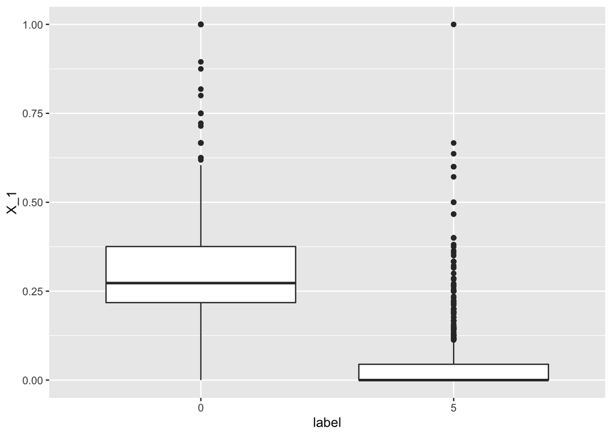

```r
dat05 %>%
  select(label, X_1, X_2) %>%
  ggplot(aes(x=label,y=X_1)) +
  geom_boxplot()
```

We see a pronounced relationship between the the predictor $X_1$ and the label (e.g. the $X_1$ feature is high for the t-shirts and low for the sandals, which make sense).

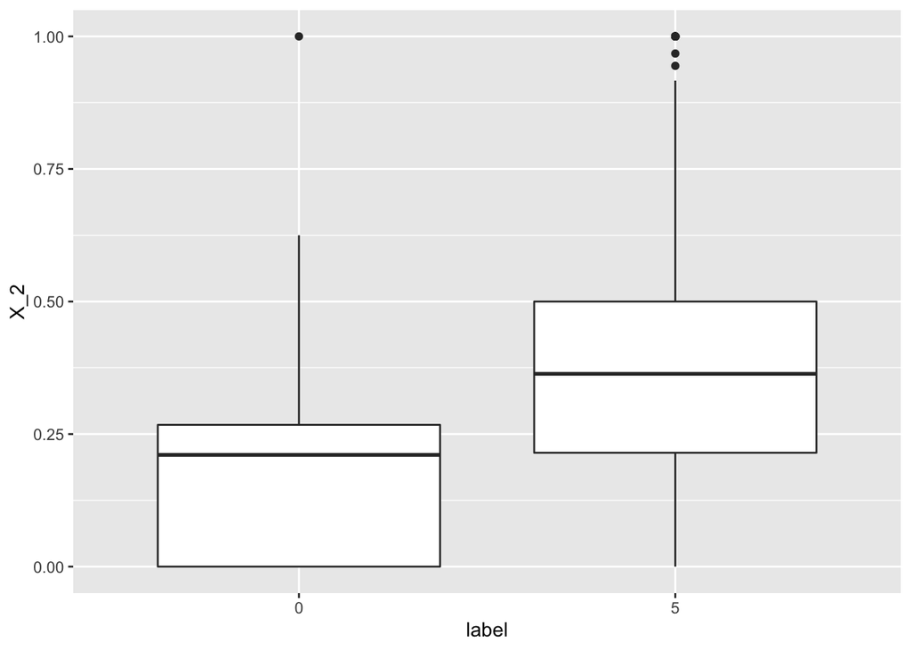

```r
dat05 %>%
  select(label, X_1, X_2) %>%
  ggplot(aes(x=label,y=X_2)) +
  geom_boxplot()
```

In this case, we again see a difference in the distribution of $X_2$ across the t-shirts and sandals, but less so. This is still likely to be informative.

Furthermore, we can also plot the relationship between $X_1$ and $X_2$ and see that there is separation between the `0`s (t-shirts)`and`5`s (sandals):

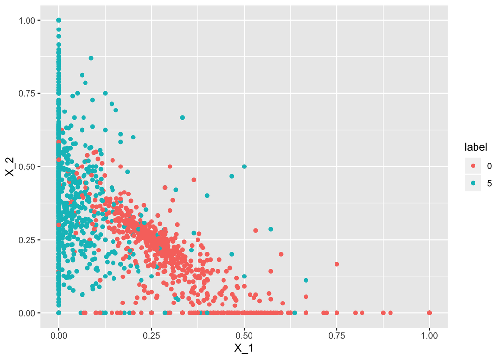

```r
dat05 %>%
  select(label, X_1, X_2) %>%
  ggplot(aes(x=X_1,y=X_2, color = label)) +
  geom_point()
```

## Create `train_set` and `test_set`

In this last step of data wrangling, we will split the `dat05` dataset into two parts:

1. `train_set` = the dataset we will use to build the classifer
2. `test_set` = the dataset we will use to assess how we are doing (not used to train the classifier)

For this we will use the `createDataPartition()` function in the `caret` package, which you have already learned about in the last lecture. We set the seed so we will all get the same answer

```r
set.seed(123)
inTrain <- createDataPartition(y = dat05$label,
                               p=0.5)
train_set <- slice(dat05, inTrain$Resample1)
test_set <- slice(dat05, -inTrain$Resample1)
```

# Linear methods for classification

## Linear regression

One approach would be to just try using simple linear regression.

This assumes that:

$$f(x) = \mbox{Pr}( Y = 1 | X_1=x_1, X_2 = x_2) = \beta_0 + \beta_1 x_1 + \beta_2 x_2$$

and we estimate $\beta_0$, $\beta_1$, $\beta_2$ with least squares. Once we have estimates $\hat{\beta}_0$, $\hat{\beta}_1$, and $\beta_2$ we can obtain an actual prediction rule:

$$\hat{f}(x) = \hat{\beta}_0+ \hat{\beta}_1 x_1 + \hat{\beta}_2 x_2$$

The problem with using linear regression is that to predict $Y$ on the basis of predictors $\mathbf{X}_i$, we will need to order the outcomes.

Does it make sense here? Not quite. Why?

If $Y$ is not quantiative (e.g. ten types of fashion pieces), it doesn’t quite make sense to put a “t-shirt” ahead of a “sandal” or behind a “pants”. This is because to use linear regression, we have to decide on an ordering and if we picked a differentordering, then that coding would produce a fundamentally different linear model with a different set of predictions on the test observations.

However, if the response variable’s values did take on a natural ordering, such as mild, moderate, and severe, and we felt the gap between mild and moderate was similar to the gap between moderate and severe, then a 1, 2, 3 coding would be reasonable.

Unfortunately, in general there is no natural way to convert a qualitative response variable with more than two levels into a quantitative response that is ready for linear regression.

## Logistic regression

If the qualitative response is binary (`0` and `1`), then one approach is to fit a linear regression to this binary response and predict `1` if the predicted response ($\hat{Y}$) is $\hat{Y} > 0.5$ or `0` otherwise.

So if we consider our linear regression model above:

$$f(x) = \mbox{Pr}( Y = 1 | X_1=x_1, X_2 = x_2) = \beta_0 + \beta_1 x_1 + \beta_2 x_2$$

We note that the expression on the right can be any real number while the expression on the left is bounded between 0 and 1.

An extension that permits us to continue using regression-like models is to apply transformations that eliminate this disconnect. In the case of binary data the most common approach is to fit a *logistic regression* model which makes use of the *logit* transformation:

$$g(p) = \log \frac{p}{1-p}$$
and use this model instead:

$$g(\mbox{Pr}(Y=1 \mid X_1=x_1 , X_2 = x_2) =
\beta_0 + \beta_1 x_1 + \beta_2 x_2$$

We can fit a logistic regression model using the `glm()` function with the `family="binomial"` argument.

```r
fit_glm <- glm(y ~ X_1, X_2, data = select(train_set, y, X_1, X_2),
               family = "binomial")
summary(fit_glm)
```

```
##
## Call:
## glm(formula = y ~ X_1, family = "binomial", data = select(train_set,
##     y, X_1, X_2), weights = X_2)
##
## Deviance Residuals:
##     Min       1Q   Median       3Q      Max
## -2.4749  -0.1421   0.0000   0.2200   2.5372
##
## Coefficients:
##             Estimate Std. Error z value Pr(>|z|)
## (Intercept)   3.0146     0.3234   9.321   <2e-16 ***
## X_1         -21.2373     2.3318  -9.108   <2e-16 ***
## ---
## Signif. codes:  0 '***' 0.001 '**' 0.01 '*' 0.05 '.' 0.1 ' ' 1
##
## (Dispersion parameter for binomial family taken to be 1)
##
##     Null deviance: 343.43  on 818  degrees of freedom
## Residual deviance: 161.91  on 817  degrees of freedom
## AIC: 83.613
##
## Number of Fisher Scoring iterations: 6
```

Next, if we predict or *classify* how each observation $Y_i$ is doing using the `predict()`

```r
pred_glm <- predict(fit_glm, newdata = test_set, type="response")
y_hat_glm <- factor(ifelse(pred_glm > 0.5, 1, 0))
tab <- table(pred=y_hat_glm, truth= test_set$y)
conf_matrix <- confusionMatrix(tab)
conf_matrix
```

```
## Confusion Matrix and Statistics
##
##     truth
## pred   0   1
##    0 446  50
##    1  54 450
##
##                Accuracy : 0.896
##                  95% CI : (0.8754, 0.9142)
##     No Information Rate : 0.5
##     P-Value [Acc > NIR] : <2e-16
##
##                   Kappa : 0.792
##
##  Mcnemar's Test P-Value : 0.7686
##
##             Sensitivity : 0.8920
##             Specificity : 0.9000
##          Pos Pred Value : 0.8992
##          Neg Pred Value : 0.8929
##              Prevalence : 0.5000
##          Detection Rate : 0.4460
##    Detection Prevalence : 0.4960
##       Balanced Accuracy : 0.8960
##
##        'Positive' Class : 0
##
```

The confusion table can be extracted using the `$table` slot

```r
conf_matrix$table
```

```
##     truth
## pred   0   1
##    0 446  50
##    1  54 450
```

And the various performance metrics too:

```r
conf_matrix$overall["Accuracy"]
```

```
## Accuracy
##    0.896
```

We can also use the `roc()` function in the `pROC` package to plot the ROC curve comparing the sensitivity and specificity

```r
roc_glm <- roc(test_set$y, pred_glm)
```

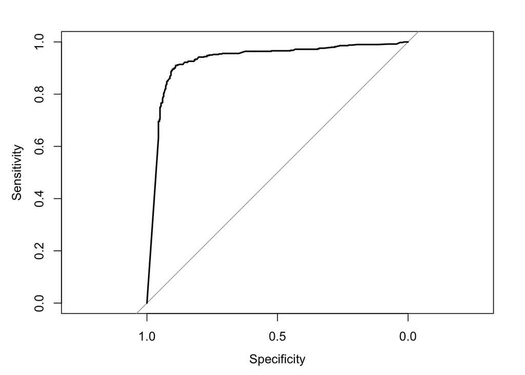

```r
plot(roc_glm)
```

### Logistic regression for more than 2 response classes

In our example, we only considered the t-shirts and sandals, but we technically have more than two classes. If the goal is to classify a response variable or outcome with more than two clasess, there are multiple-class extensions. However, in practice they tend not to be used all that often. One of the reasons is that the method we discuss in the next section, *discriminant analysis*, is popular for multiple-class classification. So we do not go into the details of multiple-class logistic regression here, but simply note that such an approach is possible, and that software for it is available in R.

## Linear discriminant analysis

Logistic regression involves directly modeling $Pr(Y = k|X = x)$ using the logistic function, for the case of two response classes. An alternative and less direct approach to estimate these probabilities is to model the distribution of the predictors $X$ separately in each of the response classes (i.e. given $Y$ ), and then use Bayes’ theorem to flip these around into estimates for $Pr(Y = k|X = x)$.

When these distributions are assumed to be normal, it turns out that the model is very similar in form to logistic regression.

Why do we need another method, when we have logistic regression? There are several reasons:

1. When the classes are well-separated, the parameter estimates for the logistic regression model are surprisingly unstable. Linear discriminant analysis does not suffer from this problem.
2. If $n$ is small and the distribution of the predictors $X$ is approximately normal in each of the classes, the linear discriminant model is again more stable than the logistic regression model.
3. Linear discriminant analysis is popular when we have more than two response classes.

Ok, let’s assume we have $K$ classes ($K \geq2$). Let $\pi_k$ represent the overall or prior probability that a randomly chosen observation comes from the $k^{th}$class or category of the response variable $Y$.

Let $f_{k}(X) ≡ Pr(X = x|Y = k)$ denote the *density function* of $X$ for an observation that comes from the $k^{th}$ class (i.e. $f_{k}(x)$ is relatively large if there is a high probability that an observation in the $k^{th}$ class has $X \approx x$, and $f_{k}(x)$ is small if it is very unlikely. Then *Bayes’ theorem* states that

$$\mbox{Pr}(Y=k|X=x) = \frac{\pi_k f_{k}(x)}{\sum_{l=1}^K \pi_l f_{l}(x)}$$

So instead of directly computing $\mbox{Pr}(Y=1|X=x)$ (i.e. if $K=2$) in logistic regression, we can plug in estimates for $\pi_k$ and $f_{k}(x)$. To do this, we make some assumptions the distributions of $f_{k}(x)$, namely that they are multivariate normal. LDA assumes that the observations within each class are drawn from a multivariate Gaussian distribution with a class-specific mean vector and a covariance matrix that is common to all $K$ classes. In our case we have two predictors ($X_1$ and $X_2$), so we assume each one is bivariate normal. This implies we need to estimate two averages, one standard deviation, and a correlation for each case $Y=1$ and $Y=0$.

This implies that we can approximate the distributions $f_{0}(X_1, X_2)$ and $f_{1}(X_1, X_2)$. We can easily estimate parameters from the data:

```r
options(digits = 2)
train_set %>% group_by(y) %>%
  summarize(avg_1 = mean(X_1),
            avg_2 = mean(X_2))
```

```
## # A tibble: 2 x 3
##       y  avg_1 avg_2
##   <dbl>  <dbl> <dbl>
## 1     0 0.303  0.174
## 2     1 0.0418 0.377
```

```r
train_set %>%
  summarize(sd = sd(X_2),
            r = cor(X_1,X_2))
```

```
## # A tibble: 1 x 2
##      sd      r
##   <dbl>  <dbl>
## 1 0.211 -0.575
```

So here are the data and contour plots showing the two normal densities:

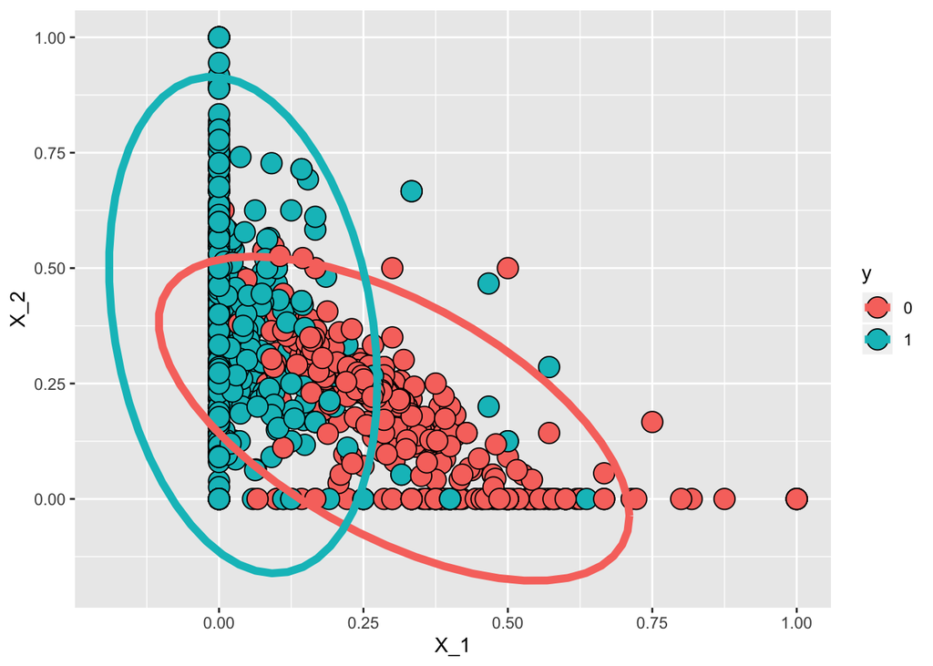

```r
train_set %>% mutate(y = factor(y)) %>%
  ggplot(aes(X_1, X_2, fill = y, color=y)) +
  geom_point(pch=21,cex=5, color="black") +
  stat_ellipse(lwd=2, type="norm")
```

We use the `lda()` function in the `MASS` R package. The `prior` argument represents the prior probability of class membership.

```r
fit_lda <- MASS::lda(y ~ ., data=dplyr::select(train_set, y, X_1, X_2),
         prior = c(1,1)/2)
pred_lda <- MASS:::predict.lda(fit_lda, test_set)$class
```

```r
tab <- table(pred=pred_lda, truth= test_set$y)
conf_matrix <- confusionMatrix(tab)
conf_matrix$table
```

```
##     truth
## pred   0   1
##    0 425  41
##    1  75 459
```

```r
conf_matrix$overall["Accuracy"]
```

```
## Accuracy
##     0.88
```

### Quadratic discriminant analysis

As we have discussed, LDA assumes that the observations within each class are drawn from a multivariate Gaussian distribution with a class-specific mean vector and a covariance matrix that is common to all $K$ classes.

*Quadratic discriminant analysis* (QDA) assumes that the observations from each class are again drawn from a Gaussian distribution and you plug in estimates for the parameters into Bayes’ theorem in order to perform prediction. However, unlike LDA, QDA assumes that each class has its own covariance matrix. That is, it assumes that an observation from the kth class is of the form $X \sim N(\mu_k,\Sigma_k)$, where $\Sigma_k$ is a covariance matrix for the kth class.

In our case we have two predictors ($X_1$ and $X_2$), so we assume each one is bivariate normal. This implies we need to estimate two averages, two standard deviations, and a correlation for each case $Y=1$ and $Y=0$.

This implies that we can approximate the distributions $f_{0}(X_1, X_2)$ and $f_{1}(X_1, X_2)$. We can easily estimate parameters from the data:

```r
options(digits = 2)
params <- train_set %>% group_by(y) %>%
  summarize(avg_1 = mean(X_1), avg_2 = mean(X_2),
            sd_1= sd(X_1), sd_2 = sd(X_2),
            r = cor(X_1,X_2))
params
```

```
## # A tibble: 2 x 6
##       y  avg_1 avg_2   sd_1  sd_2      r
##   <dbl>  <dbl> <dbl>  <dbl> <dbl>  <dbl>
## 1     0 0.303  0.174 0.166  0.143 -0.599
## 2     1 0.0418 0.377 0.0946 0.219 -0.234
```

So here are the data and contour plots showing the two normal densities:

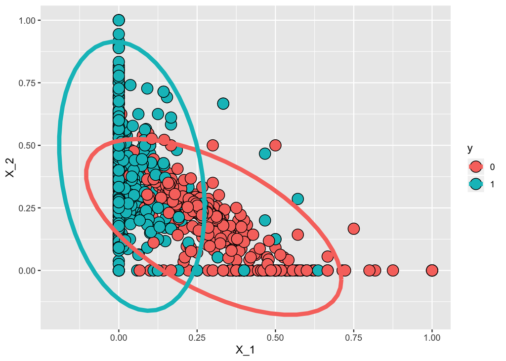

```r
train_set %>% mutate(y = factor(y)) %>%
  ggplot(aes(X_1, X_2, fill = y, color=y)) +
  geom_point(pch=21,cex=5, color="black") +
  stat_ellipse(lwd=2, type="norm")
```

We can use the `qda()` function in the `MASS` R package. The `prior` argument represents the prior probability of class membership.

```r
fit_qda <- MASS::qda(y ~ ., data=select(train_set, y, X_1, X_2),
         prior = c(1,1)/2)
pred_qda <- MASS:::predict.qda(fit_qda, test_set)$class
```

```r
tab <- table(pred=pred_qda, truth= test_set$y)
conf_matrix <- confusionMatrix(tab)
conf_matrix$table
```

```
##     truth
## pred   0   1
##    0 438  47
##    1  62 453
```

```r
conf_matrix$overall["Accuracy"]
```

```
## Accuracy
##     0.89
```

### Why does it matter if we assume a common covariance matrix?

Consequently, LDA is a much less flexible classifier than QDA, and so has substantially lower variance. This can potentially lead to improved prediction performance. But there is a trade-off: if LDA’s assumption that the $K$ classes share a common covariance matrix is badly off, then LDA can suffer from high bias.

Roughly speaking, LDA tends to be a better bet than QDA if there are relatively few training observations and so reducing variance is crucial. In contrast, QDA is recommended if the training set is very large, so that the variance of the classifier is not a major concern, or if the assumption of a common covariance matrix for the $K$ classes is clearly untenable.

## $K$-nearest neighbors

A model free alternative is the $K$-nearest neighbor classifier (KNN). Given a positive integer $K$ and a test observation $x_0$, the KNN classifier first identifies the $K$ points in the training data that are closest to $x_0$, represented by $N_0$. It then estimates the conditional probability for class $k$ as the fraction of points in $N_0$ whose response values equal $k$:

$$\mbox{Pr}( Y = k | \mathbf{X} =\mathbf{x}_0) = \frac{P(Y = k, \mathbf{X} = \mathbf{x}_0)}{P(\mathbf{X} = \mathbf{x}_0)} = \frac{1}{K} \sum_{i \in N_0} I(y_i = k)$$

Finally, KNN applies Bayes rule and classifies the test observation $x_0$ to the class with the largest probability.

Despite the fact that it is a very simple approach, KNN can often produce classifiers that are surprisingly close to the optimal Bayes classifier.

```r
fit_knn_2 <- knn3(y~., data = select(train_set, y, X_1, X_2),
                  k=2)
pred_knn_2 <- predict(fit_knn_2, newdata = test_set)[,2]

tab <- table(pred=round(pred_knn_2), truth= test_set$y)
conf_matrix <- confusionMatrix(tab)
conf_matrix$table
```

```
##     truth
## pred   0   1
##    0 462  79
##    1  38 421
```

```r
conf_matrix$overall["Accuracy"]
```

```
## Accuracy
##     0.88
```

**Note**: The choice of $K$ has a drastic effect on the KNN classifier obtained. You can explore this own your own by trying $K$ = 1 vs a larger $K$.